# Week08lab_tidytext

Akhil Havaldar

10/20/2021

### Region 1: Pacific

#### Analysis of Sentiment in Context

The Bing sentiment that we see here (in the order of LAtimes, Alaska Dispatch, The Spokesman-Review) tells us about the negativity and positivity of the newspapers. The LATimes has a very negative sentiment, which makes sense since LA is a major metropolitan city and can have multiple viewpoints on the same issue. The Alaska Dispatch has a very even split which is quite surprising as I would expect more negative things associated with climate change in Alaska since it is close to the arctic. The Spokesman-Review also has a very negative sentiment, which is consistent with the theme of LA.

```
##
## negative positive
##      136       54
```

```
##
## negative positive
##       68       67
```

```
##
## negative positive
##      104       41
```

From the NRC sentiment (in the order of LAtimes, Alaska Dispatch, The Spokesman-Review) we can see the same pattern of sentiment as with the Bing sentiment. LATimes has a lot of words associated with fear, whereas the Alaska Dispatch has a pretty even spread among the sentiment words. The Spokesman-Review had a lot of words associated with trust, but apart of that it was pretty evenly spread out.

```
##
##        anger anticipation      disgust         fear          joy     negative
##           53           51           37           89           32          108
##     positive      sadness     surprise        trust
##          135           54           33           82
```

```
##
##        anger anticipation      disgust         fear          joy     negative
##           27           45           25           46           26           79
##     positive      sadness     surprise        trust
##          151           38           15           91
```

```
##
##        anger anticipation      disgust         fear          joy     negative
##           50           41           33           58           24          113
##     positive      sadness     surprise        trust
##          123           46           23           76
```

From the histograms we can see the distributions match up with the Bing and NRC sentiments. LATimes and The Spokesman-Review have a more negative distribution, while the Alaska Dispatch has a more neutral distribution.

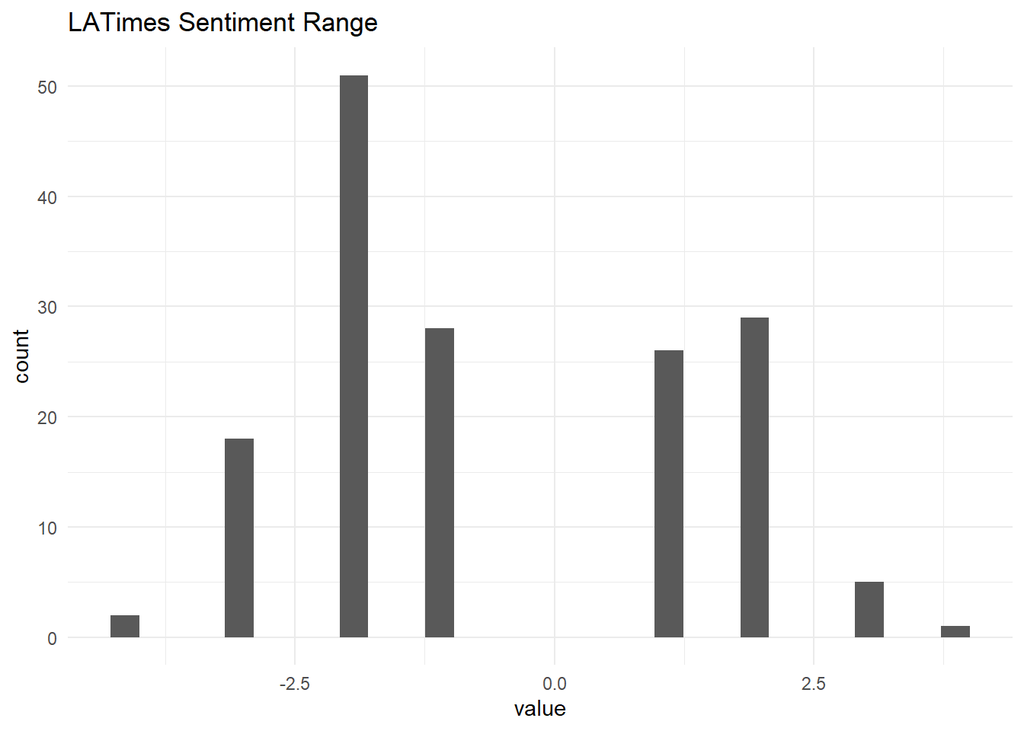

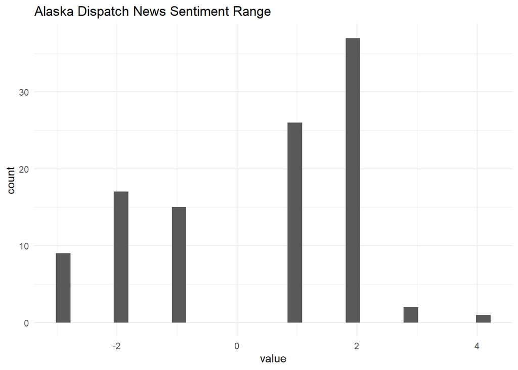

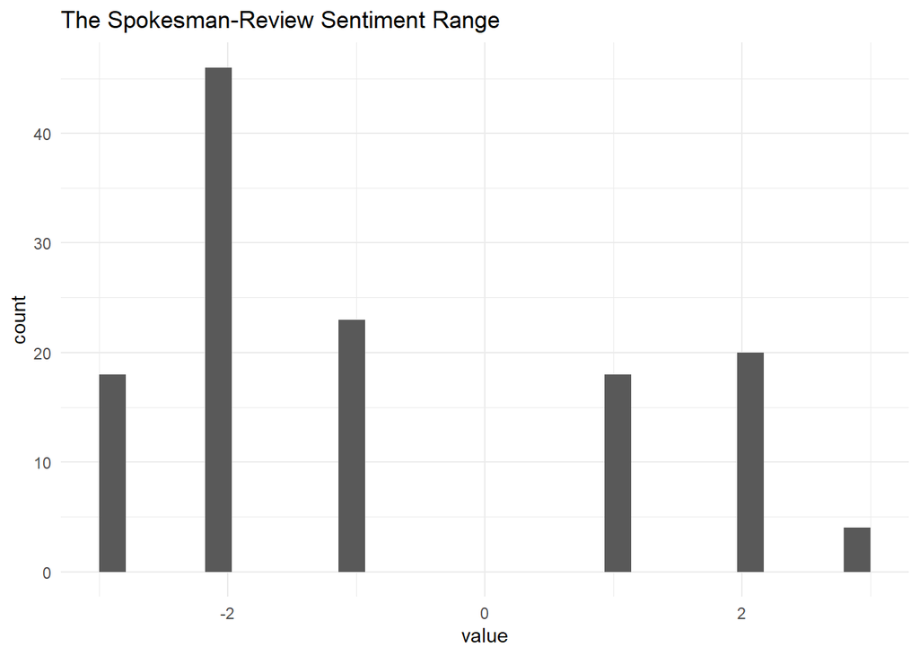

From the word clouds (in the order of LAtimes, Alaska Dispatch, The Spokesman-Review), we can just see which words appear the most in each newspaper.

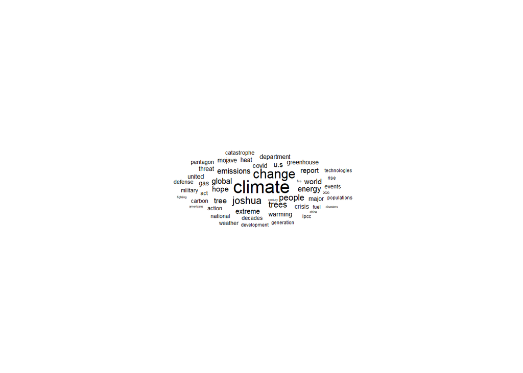

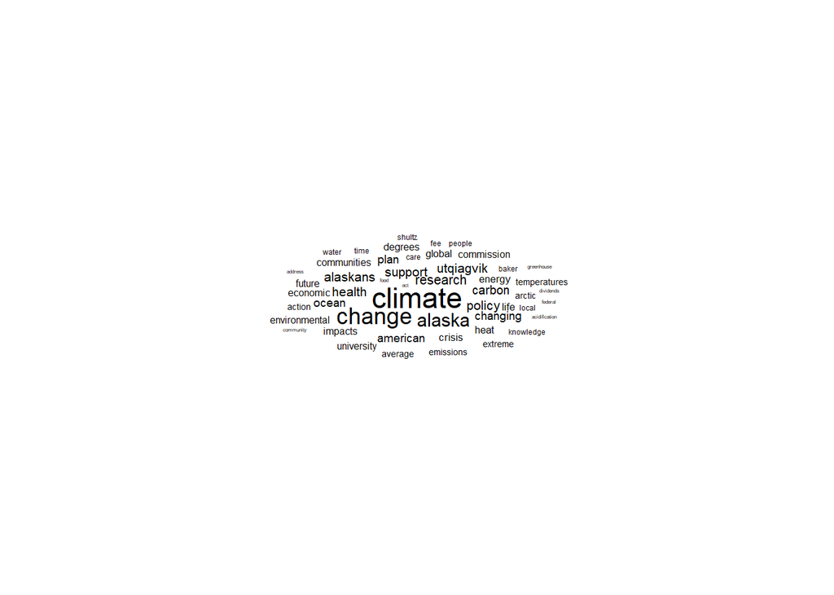

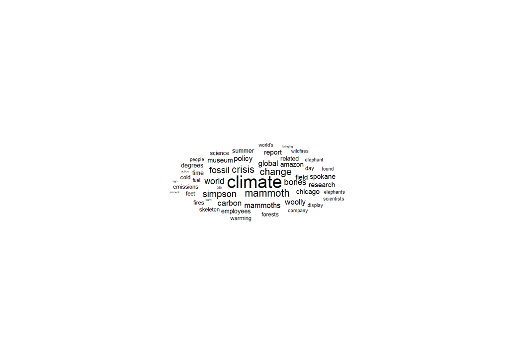

#### Analysis of TF-IDF

From the TF-IDF table the first 10 rows don’t tell us much. But after deeper analysis words like “community”, “burn”, and “challenge” have a relatively high tf-idf. One surprising thing is that many of the words are not shared across the newspapers which can make the analysis of the region harder.

```
## # A tibble: 4,776 x 7
##    newspapers           word          n total      tf   idf  tf_idf
##    <chr>                <chr>     <int> <int>   <dbl> <dbl>   <dbl>
##  1 Alaska Dispatch News alaska       26  3864 0.00673  1.10 0.00739
##  2 LATimes              joshua       18  4855 0.00371  1.10 0.00407
##  3 The Spokesman-Review mammoth      16  4489 0.00356  1.10 0.00392
##  4 The Spokesman-Review simpson      14  4489 0.00312  1.10 0.00343
##  5 The Spokesman-Review bones        12  4489 0.00267  1.10 0.00294
##  6 Alaska Dispatch News alaskans     11  3864 0.00285  1.10 0.00313
##  7 Alaska Dispatch News utqiagvik    11  3864 0.00285  1.10 0.00313
##  8 The Spokesman-Review woolly       10  4489 0.00223  1.10 0.00245
##  9 Alaska Dispatch News ocean         9  3864 0.00233  1.10 0.00256
## 10 The Spokesman-Review amazon        9  4489 0.00200  1.10 0.00220
## # ... with 4,766 more rows
```

#### Analysis of Overall Data

After looking through the analysis of the data, I can conclude that the Pacific region has a relatively negative feeling towards climate change, with a lot of the newspapers insinuating fear in their articles. From this result, the next steps would be figuring out how the people in the Pacific fear climate change. Are they fearful because they think it is a government scam or are they fearful because climate change is real and harmful? I would say the latter due to the political affiliation in the region. Once this information is obtained, it would be best to start implementing climate change counter measures in these areas. If the people are fearful of it, they should be open to change and should be working to help solve the problem. Another step would be to actively advocate for change at the government level. Only with legislation can big businesses be controlled and be held accountable for climate change.

### Region 2: Rocky Mountain

#### Analysis of Sentiment in Context

The Bing sentiment that we see here (in the order of Idaho Falls Post Register, The Salt Lake Tribune, The Wyoming Tribune) tells us about the negativity and positivity of the newspapers. The Idaho Falls has a majority negative sentiment, which, with all the natural landmarks, makes sense. The Salt Lake Tribune and The Wyoming Tribune also have a majority negative split, but The Wyoming Tribune could be considered more neutral.

```
##
## negative positive
##       69       37
```

```
##
## negative positive
##      124       68
```

```
##
## negative positive
##       70       46
```

From the NRC sentiment (in the order of Idaho Falls Post Register, The Salt Lake Tribune, The Wyoming Tribune) we can see the same pattern of sentiment as with the Bing sentiment. All three newspapers have a very strong association with trust, but apart from that are spread out evenly.

```
##
##        anger anticipation      disgust         fear          joy     negative
##           27           35           13           32           19           65
##     positive      sadness     surprise        trust
##          103           24           20           70
```

```
##
##        anger anticipation      disgust         fear          joy     negative
##           47           47           23           59           32          102
##     positive      sadness     surprise        trust
##          163           46           25           96
```

```
##
##        anger anticipation      disgust         fear          joy     negative
##           27           35           20           31           23           55
##     positive      sadness     surprise        trust
##          114           27           23           60
```

From the histograms we can see the distributions match up with the Bing and NRC sentiments. All three newspapers have a relatively similar, even distribution.

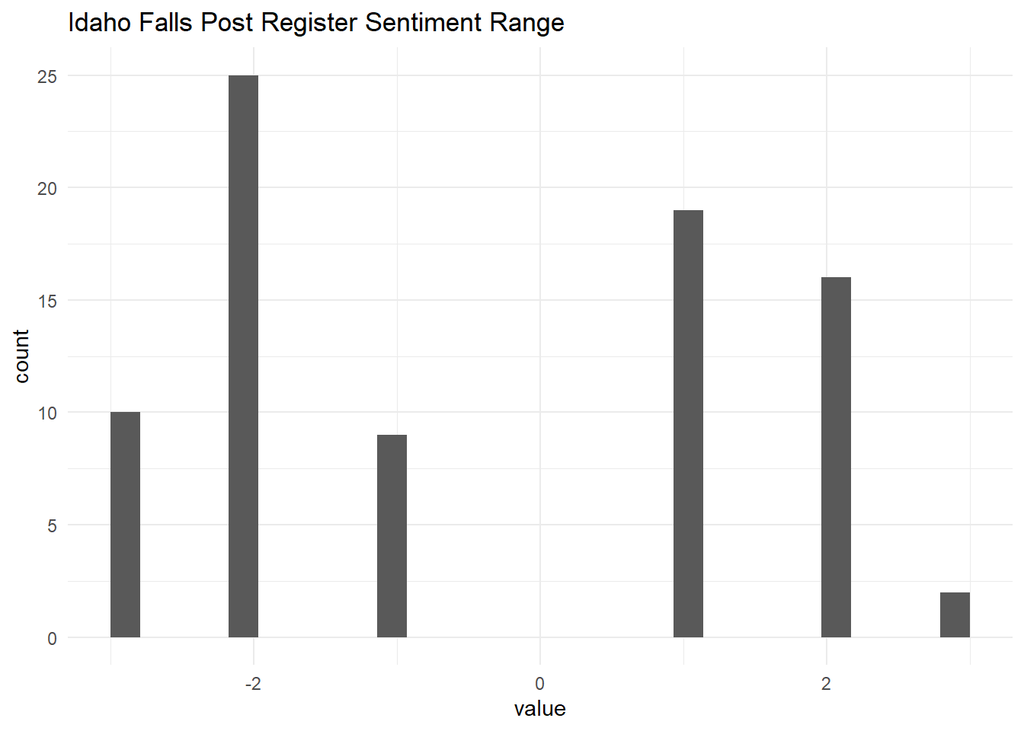

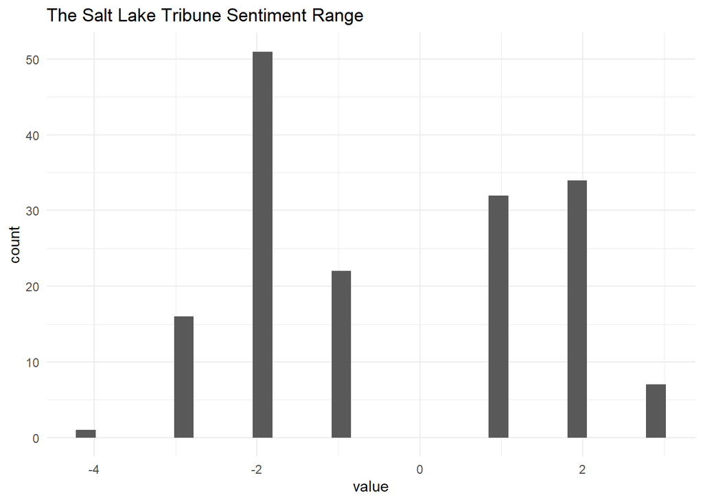

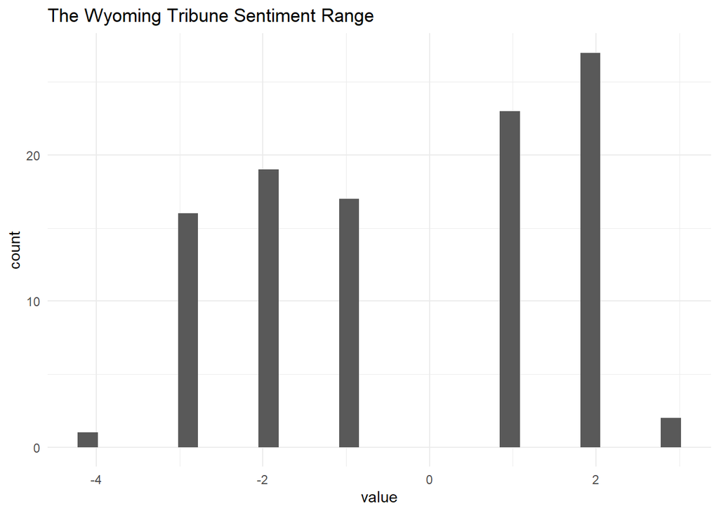

From the word clouds (in the order of Idaho Falls Post Register, The Salt Lake Tribune, The Wyoming Tribune), we can just see which words appear the most in each newspaper.

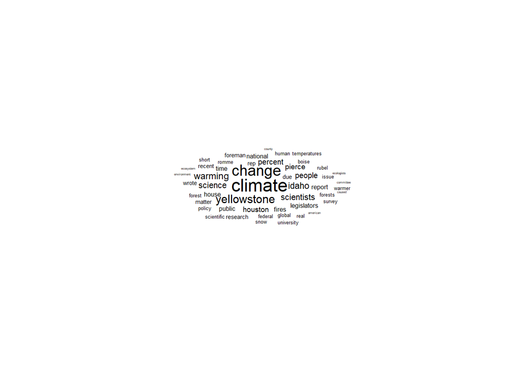

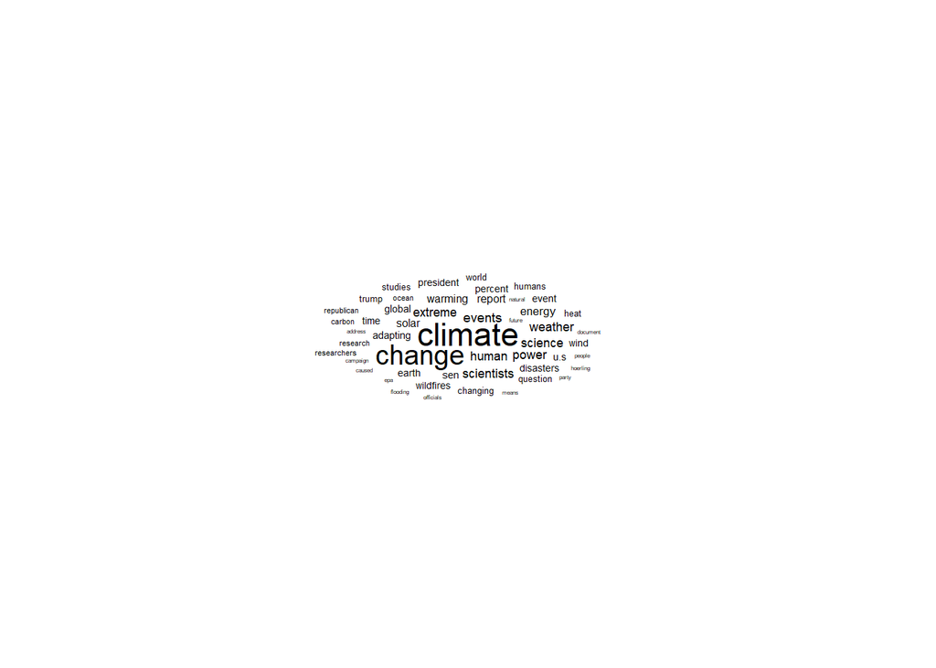

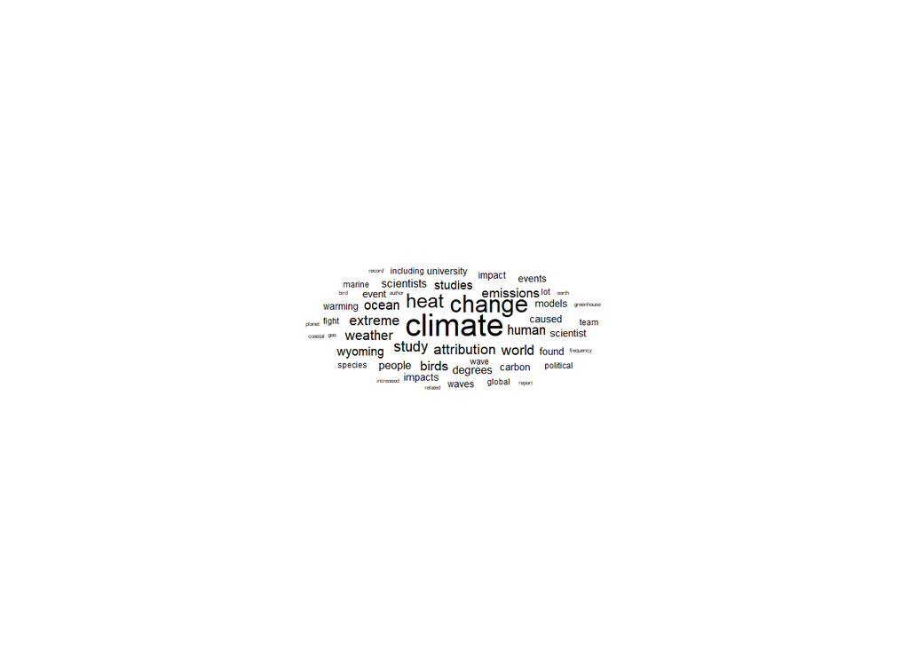

#### Analysis of TF-IDF

From the TF-IDF table the first 10 rows don’t tell us much. But after deeper analysis words like “adapting” and “extremes” have a relatively high tf-idf.

```
## # A tibble: 4,252 x 7
##    newspapers                word            n total      tf   idf  tf_idf
##    <chr>                     <chr>       <int> <int>   <dbl> <dbl>   <dbl>
##  1 The Salt Lake Tribune     s              24  5491 0.00437  1.10 0.00480
##  2 Idaho Falls Post Register yellowstone    20  3388 0.00590  1.10 0.00649
##  3 Idaho Falls Post Register idaho          12  3388 0.00354  1.10 0.00389
##  4 The Wyoming Tribune       birds          11  3552 0.00310  1.10 0.00340
##  5 The Salt Lake Tribune     adapting       10  5491 0.00182  1.10 0.00200
##  6 Idaho Falls Post Register houston         8  3388 0.00236  1.10 0.00259
##  7 Idaho Falls Post Register pierce          8  3388 0.00236  1.10 0.00259
##  8 Idaho Falls Post Register legislators     7  3388 0.00207  1.10 0.00227
##  9 Idaho Falls Post Register foreman         6  3388 0.00177  1.10 0.00195
## 10 Idaho Falls Post Register wrote           6  3388 0.00177  1.10 0.00195
## # ... with 4,242 more rows
```

#### Analysis of Overall Data

After running the initial sentiment analysis there seems to be a negative feeling towards climate change. However, after looking at the graphs and more sentiment analysis, there seems to be a feeling of trust and a relatively spread out distribution. This tells me there is not enough alarm in the Rocky Mountain region about climate change. The next steps should be to raise awareness about climate change in this region. Advertisements, political advocacy, and taxes are a few ways to do so. By showing the people the problems caused by climate change (and by taxing them a few dollars), people should start to feel more negative towards the topic, making change a greater possibility.